# Democracy and Human Capital: Experimental Evidence from Burkina Faso

Authors

Affiliations

Yasuyuki Sawada

Faculty of Economics, University of Tokyo

Takeshi Aida

Graduate School of Economics, Hitotsubashi University

Andrew S. Griffen

Faculty of Economics, University of Tokyo

Harounan Kazianga

Department of Economics, Oklahoma State University

Eiji Kozuka

Faculty of International Relations, University of Shizuoka

Haruko Noguchi

Faculty of Political Science and Economics, Waseda University.

Yasuyuki Todo

Faculty of Political Science and Economics, Waseda University.

Eiji Yamada

JICA Ogata Research Institute

## Abstract

We report impacts from a randomized controlled trial (RCT) of democratic school governance decentralization on children’s health and education outcomes in rural Burkina Faso. In treated schools, school-based management (SBM) members were selected by community-wide secret voting and implemented school reforms using community feedback. We find impacts across a range of human capital outcomes for children. Our results have implications for the introduction of local democratic institutions in developing countries to improve service delivery in schools and to affect children’s human capital formation.

## Introduction

We report impacts from a large-scale, school-level RCT in rural Burkina Faso of a school-based management (SBM) program called COGES[^1]. SBM is a form of school governance decentralization that aims to leverage local control in an attempt to improve school quality and service delivery (*1*–*5*). This is particularly important in developing countries given poor school quality and substantial absenteeism among teachers (*6*, *7*). Although there is much hope for schools as a vehicle to improve children’s human capital in developing countries, the available evidence suggests that increases in inputs without accountability or governance reforms are unlikely to improve outcomes (*3*, *8*, *9*).

In our RCT, treated schools conducted secret-ballot, community-wide democratic elections for COGES members. These democratically elected members then had the power to make changes within the schools using input from the local community. Typical changes in the schools included constructing toilets specifically for female students, providing school lunch, improving school infrastructure (e.g., classrooms, desks, and chairs), and arranging housing for teachers. Our intervention did not transfer any resources to the schools, which is consistent with evidence that the limiting factor of effective schools is governance and incentives and not resources (*10*). These two features of our intervention, elections and no transfers, were intended to address some potential political economy issues such as lack of broad-based participation and elite capture (*2*, *5*).

We find large, short-term, one-year impacts of COGES on measures of children’s human capital. Consistent with its aim to improve schools, COGES reduced teacher absence and improved service provision to children via meals provided at the school. We find subsequent impact on health outcomes: decreases in the incidence of very-low weight, malnourishment, and various diseases among the children. These impacts are concentrated among female students and are plausibly driven by increases in nutrition. Although teacher attendance improved, we find no impacts on test scores, student attendance, and grade repetition, which suggests some limits to the benefits of decentralization and is consistent with many challenges to improve learning outcomes(*7*, *8*). However, improved service delivery and the COGES itself provides a mechanism for adaptive improvements in the future.

Although SBMs are widespread and politically popular, there currently exist only a few randomized evaluations of SBMs (*11*). Further, each SBM is invariably unique given the wide variety of policy levers from “strong” to “weak” forms of decentralization across an autonomy-participation axis (*12*). For generalizability, it is important to understand SBMs across a wide variety of contexts, especially in environments such as Burkina Faso with weaker democratic institutions (*13*, *14*). Our paper is also connected to the larger literature on the role of democracy in development. At the macroeconomic level, there have been extensive debates about democracy (*15*, *16*) and some effective authoritarian regimes in Asia (Singapore under Lee Kuan Yew, South Korea under Park Chung-hee, and modern China) have cast doubt on its importance. Even within democracies, there is evidence that the interests of the poor are not adequately represented (*17*). Our study provides rigorous causal evidence on the micro-foundations of development and democratic decentralization (*18*), helps to unpack some of the mechanisms behind observed relationships between democracy and improvements in health outcomes (*19*, *20*), and demonstrates that micro-governance reforms can indeed help to strengthen the SDGs (*21*), which includes inclusive and quality education.

## RCT

Figure 1 shows a map of Ganzourgou Province within Burkina Faso as well as the location of schools within the province. Treatment schools are blue and control schools are yellow. Squares are used in the map to represent the 2.6% of schools assigned to control that implemented COGES (“crossovers”) and the 4.4% of treatment schools that delayed implementing COGES (“no-shows”). We employ standard statistical techniques to account for this randomization noncompliance (*22*).

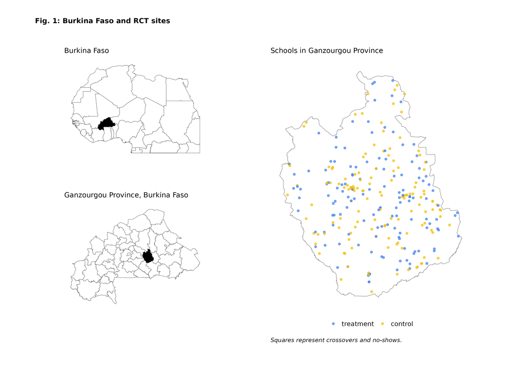

## Data

We have survey data on health and education outcomes collected from children, parents, and schools principals. This survey data is supplemented with school records, anthropometric measurements collected by trained teams, and provincial level data. Data were measured at both the school and individual level. Baseline data were collected in December 2009 and January 2010. Endline data were collected in January and February 2011. Table 1 reports tests of pre-treatment balance in which the data are grouped by domain (education and health) and measurement level ($I$ individuals nested within $S$ schools or schools). We cannot reject the null hypothesis for any baseline outcome variable. In general the health data is more likely to be missing and we have baseline test scores for only a fraction of the students. In addition to the individual level data, some of the school level variables (e.g., student attendance) can also be disaggregated by gender, which we use to explore heterogeneous effects by student gender.

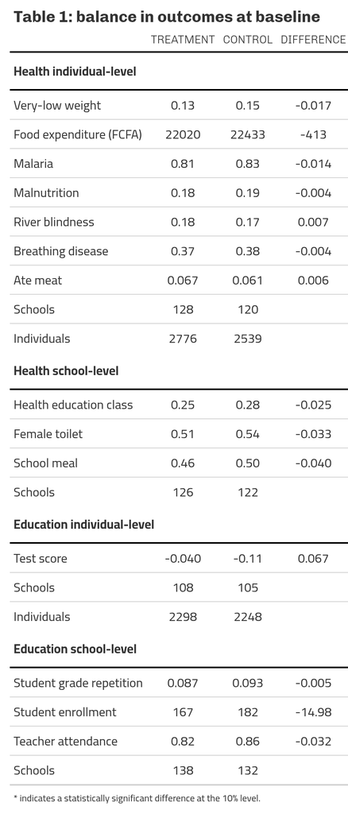

For health outcomes, we have household survey data on whether the children were sick with malnutrition, malaria, breathing disease, and river blindness[^2]. These variables are all coded yes = 1 and no = 0 for the presence of the disease or condition. We also collected data on children’s height (m) and weight (kg), which was used to construct Rohrer’s index $(10\frac{kg}{m^3})$. We define very-low weight as a value of Rohrer’s index less than 100 (very-low weight = 1, otherwise = 0). We also have data on some health inputs such as monthly expenditure on food at the household level (FCFA) and whether the child ate meat in the last week (yes = 1, no = 0). From the school-level survey, we have information on provision of school meal and presence of a toilet for female students (yes = 1, no = 0).

For education outcomes, we have data on teacher attendance collected from random unannounced spot-checks, whether the school offered a health education class or not, student grade repetition, and student enrollment. Again these variables are coded yes = 1 and no = 0. We also have provincial level data on student test scores. The tests covered various topics in reading, writing, and mathematics and differed across grades and time. Using the control group, we normalized each test score separately by grade and exam. We then took the average scaled score across exams for each student.

We estimate the impact of COGES using the following regression model,
$$Y_{ise} = \alpha_0 + \alpha_1 COGES_{s} + \alpha_2 Y_{isb} + \beta X_{isb} + \mu_s + \epsilon_{ise},$$

where $Y_{ise}$ is the health or education outcome for child $i$ in school $s$ at endline $e$. The variable $COGES_{s}$ is an indicator that equals 1 if school $s$ implemented COGES, and 0 otherwise. We also have controls for baseline outcome $Y_{isb}$, baseline control variables $X_{isb}$ and strata level effects $\mu_s$. Unobserved variables are represented by $\epsilon_{ise}$. Some outcomes are measured only at the school level $s$ in which case we drop $i$.

For binary outcomes, this is a linear probability model so the coefficient $\alpha_1$ is scaled in percentage points. Test scores have already been normalized so the coefficient is interpreted as an effect size. For other continuous outcomes (food expenditure and student enrollment), we log the outcome variable so that coefficient on $COGES_s$ is interpreted as a percentage change. When possible we also estimate separate models by gender to investigate effect heterogeneity. Finally we also use a forest plot to show the impacts in effect size units in order to put the impacts on a common scale.

To account for imperfect compliance to random assignment, we use random assignment to COGES as an instrumental variable (IV) for actual implementation of COGES ($COGES_s$). The IV parameter estimate can then be interpreted as a local average treatment effect (LATE), which is the effect of COGES on the unobserved subpopulation of compliers (*22*)[^3].

## Results

The impact estimates are displayed in table 2. The first column (1) shows the main impact estimates with only controls for baseline outcome variable, student sex/age, and strata fixed effects. We find statistically significant impacts on the provision of school meals (6.8 percentage points (pp)) as well as decreases in the incidence of very low-weight (-4.7 pp), malnutrition (-3.4 pp), and malaria (-4 pp). The program appears to crowd out food expenditures in the house (-14%), which is common for food supplement programs. However, the decrease in very low-weight and malnutrition is evidence of the transfer “sticking” to the child (*25*, *26*). In column (2), if we add additional controls for enrollment and percentage girls in the school at baseline, we see further statistically significant decreases in breathing disease (-4.3 pp) and river blindness (-3.7 pp). We interpret the increased statistical precision as coming from the density and age distribution within schools affecting the presence of these diseases.

For education outcomes, we see improvements in teacher attendance (7.6 pp) but no effects on student enrollment or grade repetition. We also do not see any effects on test scores. However, this is possibly explained by the relatively short time frame as test scores were collected only six months after the COGES elections.

We also examined effect heterogeneity by gender. In column (3) the sample is restricted to female students and to male students in column (4). Interestingly most of the decreases in diseases are concentrated among female students. In addition, the decrease in the incidence of very low-weight is larger for females (-5.1 than for males -3.7).

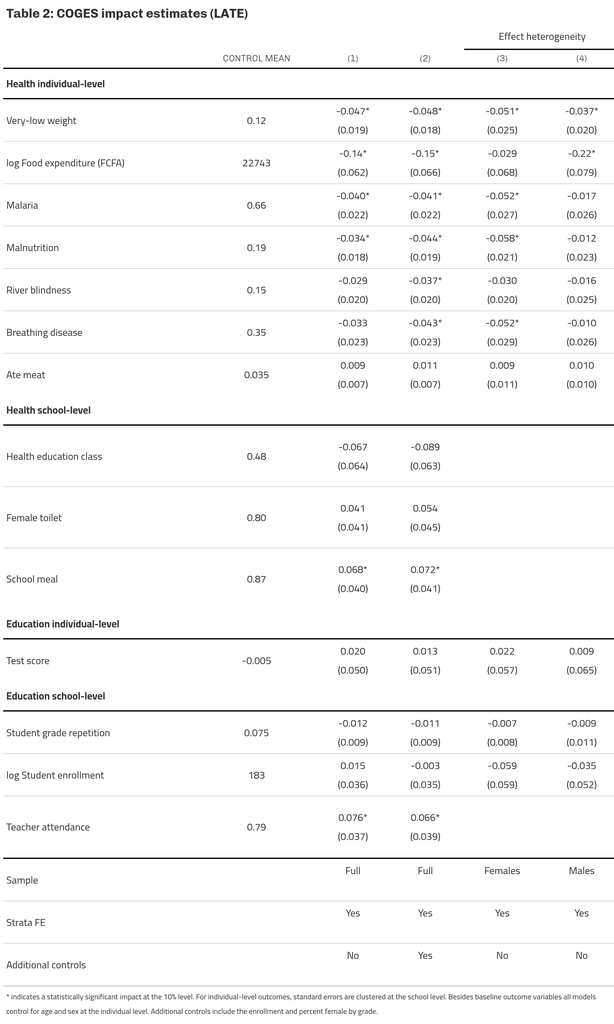

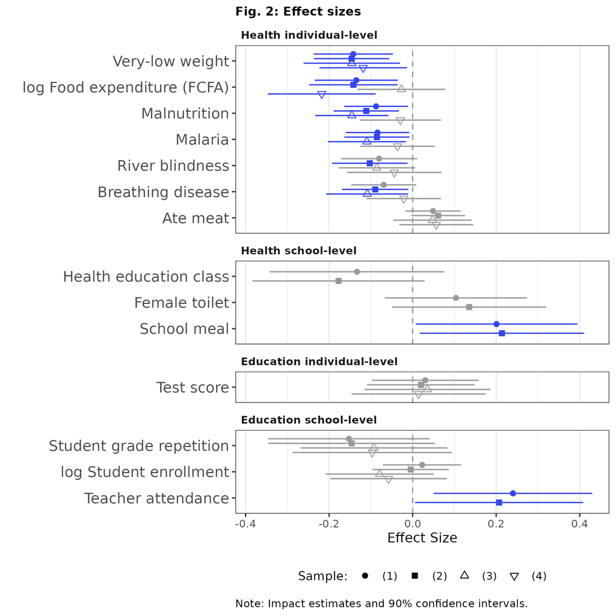

## Discussion

The pattern of results show large short-term impacts of COGES on variables related to children’s human capital. We find more impacts in the health domain and particularly large impacts for female students. The results also suggest some of the likely mechanisms. For health, improvements in children’s health measures is plausibly connected to improvements in nutrition via school meals. In our context, the impacts do not seem to operate through other channels such as sanitation via female toilets, health education, or eating meat.

Consistent with its aim to better reflect parents’ preferences, COGES also arguably improved school governance via increased provision of school meals and improved teacher attendance. Interestingly the school meals were provided by community members, which suggests that the exogenous introduction of the COGES and elections created an endogenous response within the community. In a companion paper (*27*), we show that COGES increased social capital in the villages, which is consistent with this story. We also document that the elected COGES committees were composed of 40% women. COGES seems to provide a mechanism for school policy to better reflect preferences within the community such as increased investment in girls and more representation by women (*28*).

Unfortunately, increased teacher attendance did not seem to translate into improved enrollment, grade repetition, or test scores. These results are consistent with evidence that rural schools in developing countries are operating far from the efficient knowledge production frontier (*7*) so that increased inputs do not necessarily translate into improved learning outcomes, which has been an ongoing challenge in education policy in developing countries (*8*).

## Conclusion

In this paper, we report impacts of an SBM program called COGES on human capital outcomes for children in Burkina Faso. The results suggest that decentralized and democratic processes can be a powerful tool for reforming educational institutions so that parent and community voices are reflected in decision-making and resource allocation. We show that this led to increased productive efficiency within the schools and improvements in children’s human capital in our study villages in Burkina Faso. Such micro-level evidence on both the introduction and randomization of elections and democratic institutions is quite rare (*11*, *29*) and can add to the evidence base around decentralization and local control (*5*). Also of interest for policy is that the villages raised their own resources, which shows the democratic institutions can facilitate financing to help solve collective action problems. Our research also provides broader insight into the role of the community in developing countries. Market failures can prevent productive and efficient investment in children. This, in principle, can be countered by government intervention. However, developing countries often feature weak and ineffectual states (*14*). It has been hypothesized that the community can substitute as an effective institution and leverage social capital to promote voluntary cooperation and realize efficient outcomes (*30*–*33*). Our results provide empirical support for this hypothesis. In complementary work, we find that COGES increased social capital in the treatment villages (*27*) and this current work shows clear changes in school inputs and subsequent changes in children’s human capital outcomes. Larger impacts for female students provide indirect evidence that previous policies did not necessarily reflect the broader preferences of the parents and the community. As policymakers debate the trajectory of the SDGs (*21*), our work highlights that decentralization and democracy can be an effective combination to promote investments in children in development countries consistent with the aims of the SDGs.

## References

1.

K. Casey, R. Glennerster, E. Miguel, Reshaping institutions: Evidence on aid impacts using a preanalysis plan. *Quarterly Journal of Economics* **127**, 1755–1812 (2012).

2.

G. Mansuri, V. Rao, *Localizing Development: Does Participation Work?* (The World Bank, 2013).

3.

E. Duflo, P. Dupas, M. Kremer, School governance, teacher incentives, and pupil–teacher ratios: Experimental evidence from kenyan primary schools. *Journal of Public Economics* **123**, 92–110 (2015).

4.

M. Björkman Nyqvist, D. De Walque, J. Svensson, Experimental evidence on the long-run impact of community-based monitoring. *American Economic Journal: Applied Economics* **9**, 33–69 (2017).

5.

K. Casey, Radical decentralization: Does community-driven development work? *Annual Review of Economics* **10**, 139–163 (2018).

6.

N. Chaudhury, J. Hammer, M. Kremer, K. Muralidharan, F. H. Rogers, Missing in action: Teacher and health worker absence in developing countries. *Journal of Economic Perspectives* **20**, 91–116 (2006).

7.

A. Eble, C. Frost, A. Camara, B. Bouy, M. Bah, M. Sivaraman, P.-T. J. Hsieh, C. Jayanty, T. Brady, P. Gawron, others, How much can we remedy very low learning levels in rural parts of low-income countries? Impact and generalizability of a multi-pronged para-teacher intervention from a cluster-randomized trial in the gambia. *Journal of Development Economics* **148**, 102539 (2021).

8.

M. Kremer, C. Brannen, R. Glennerster, The challenge of education and learning in the developing world. *Science* **340**, 297–300 (2013).

9.

I. M. Mbiti, The need for accountability in education in developing countries. *Journal of Economic Perspectives* **30**, 109–32 (2016).

10.

A. V. Banerjee, R. Banerji, E. Duflo, R. Glennerster, S. Khemani, Pitfalls of participatory programs: Evidence from a randomized evaluation in education in india. *American Economic Journal: Economic Policy* **2**, 1–30 (2010).

11.

M. Pradhan, D. Suryadarma, A. Beatty, M. Wong, A. Gaduh, A. Alisjahbana, R. P. Artha, Improving educational quality through enhancing community participation: Results from a randomized field experiment in indonesia. *American Economic Journal: Applied Economics*, 105–126 (2014).

12.

H. A. Patrinos, T. Fasih, *Decentralized Decision-Making in Schools: The Theory and Evidence on School-Based Management* (World Bank Publications, 2009).

13.

F. House, *Freedom in the World 2011: The Annual Survey of Political Rights and Civil Liberties* (Rowman & Littlefield, 2011).

14.

F. Finan, B. A. Olken, R. Pande, The personnel economics of the developing state. *Handbook of economic field experiments* **2**, 467–514 (2017).

15.

R. J. Barro, Democracy and growth. *Journal of Economic Growth* **1**, 1–27 (1996).

16.

D. Acemoglu, S. Naidu, P. Restrepo, J. A. Robinson, Democracy does cause growth. *Journal of Political Economy* **127**, 000–000 (2019).

17.

R. Pande, Can democracy work for the poor? *Science* **369**, 1188–1192 (2020).

18.

B. R. Weingast, Second generation fiscal federalism: Political aspects of decentralization and economic development. *World Development* **53**, 14–25 (2014).

19.

T. Besley, M. Kudamatsu, Health and democracy. *American economic review* **96**, 313–318 (2006).

20.

T. J. Bollyky, T. Templin, M. Cohen, D. Schoder, J. L. Dieleman, S. Wigley, The relationships between democratic experience, adult health, and cause-specific mortality in 170 countries between 1980 and 2016: An observational analysis. *The Lancet* **393**, 1628–1640 (2019).

21.

F. Biermann, Y. Sun, D. Banik, M. Beisheim, M. J. Bloomfield, A. Charles, P. Chasek, T. Hickmann, P. Pradhan, C.-A. Sénit, Four governance reforms to strengthen the SDGs. *Science* **381**, 1159–1160 (2023).

22.

G. W. Imbens, J. D. Angrist, Identification and estimation of local average treatment effects. *Econometrica* **62**, 467–475 (1994).

23.

P. E. Todd, K. I. Wolpin, The production of cognitive achievement in children: Home, school, and racial test score gaps. *Journal of Human Capital* **1**, 91–136 (2007).

24.

E. Miguel, M. Kremer, Worms: Identifying impacts on education and health in the presence of treatment externalities. *Econometrica* **72**, 159–217 (2004).

25.

M. Islam, J. Hoddinott, Evidence of intrahousehold flypaper effects from a nutrition intervention in rural Guatemala. *Economic Development and Cultural Change* **57**, 215–238 (2009).

26.

H. G. Jacoby, Is there an intrahousehold “flypaper effect”? Evidence from a school feeding programme. *The Economic Journal* **112**, 196–221 (2002).

27.

Y. Sawada, T. Aida, A. S. Griffen, E. Kozuka, H. Noguchi, Y. Todo, Democratic institutions and social capital: Experimental evidence on school-based management from a developing country. *Journal of Economic Behavior & Organization* **198**, 267–279 (2022).

28.

G. Grossman, T. Slough, Government responsiveness in developing countries. *Annual Review of Political Science* **25**, 131–153 (2022).

29.

S. I. Lindberg, M. Lundstedt, F. Wiebrecht, V. Boese-Schlosser, K. Morrison, N. Natsika, Y. Sato, Impact of democracy on economic, human, and societal development. *Humanities and Social Sciences Communications* **13**, 625 (2026).

30.

Y. Hayami, Social capital, human capital and the community mechanism: Toward a conceptual framework for economists. *Journal of Development Studies* **45**, 96–123 (2009).

31.

R. Rajan, Communities, the state, and markets: The case for inclusive localism. *Oxford Review of Economic Policy* **37**, 811–823 (2021).

32.

S. Bowles, H. Gintis, Social capital and community governance. *Economic Journal* **112**, F419–F436 (2002).

33.

M. Ogaki, Economics of the community mechanism. *Japanese Economic Review* **73**, 433–457 (2022).

## Footnotes

[^1]: The acronym comes from the French “projet d’appui COmités de Gestion dans des EcoleS primaires”.
[^2]: The questionnaire asks whether the child has ever been treated/vaccinated against a list of diseases. We focus on diseases without vaccines. Further, our interpretation assumes that sick children receive treatment so that a lower percentage is evidence of less disease (and not less treatment). The question also asks whether the child was “ever treated”, however, because we control for baseline measures of disease, these models are similar to “value-added” models (*23*) that capture the outcome between endline and baseline.
[^3]: We also tried accounting for spillovers between treatment and control villages based on distance (*24*) under the theory that ideas on how to improve schools via COGES like mechanisms might spread to control villages and attenuate the impacts. However, the results were very similar to the results presented here.